# visualization

Do Won Kim

2024-03-12

# 1 Scatter Plot

> Ro’ee: I think it would be useful at some point to create a scatter plot with WTA in round 1 in the x-axis and round 2 in the y-axis (and also just report the correlation). It’s a bit surprising that so many people provided a different answer, we should figure out if this is related to the question wording.

## 1.1 Plot 1.

- 14 cases removed (over $100)

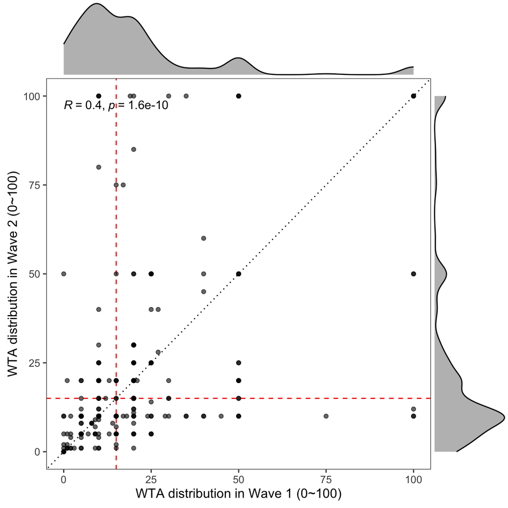

```r
library(tidyverse)
library(ggplot2)
library(DT)
library(haven)
library(ggpubr)
library(cowplot)
library(ggthemes)
library(readr)
library(ggExtra)
library(scales)
wta_df <- read_csv("wta/wta_df.csv", col_types = cols(userid = col_character(),
                                                      wta_w1 = col_integer(),
                                                      wta_w2 = col_integer(),
                                                      w2_compre1 = col_integer(),
                                                      w2_compre2 = col_integer()))


plot0 <- ggplot(wta_df, mapping = aes(wta_w1, wta_w2)) +
  geom_abline(intercept = 0, slope = 1, lty = 3, color = 'black') +
  geom_hline(yintercept = 15, lty = 2, color = 'red') +
  geom_vline(xintercept = 15, lty = 2, color = 'red') +
  geom_point(alpha=0.6) +
  stat_cor(method = 'pearson') +
  xlim(c(0, 100)) +
  ylim(c(0, 100)) +
  theme_few() +
  theme(legend.position = 'bottom') +
  xlab('WTA distribution in Wave 1 (0~100)') +
  ylab('WTA distribution in Wave 2 (0~100)')

ggMarginal(plot0, fill='gray')
```

## 1.2 Plot 2.

- Group by WTA group assigned in Wave 1
  - `assigned_wta_w1`: In Wave 1, what condition was the user assigned to
    - `scale_within`: user chose a number within 0~30 scale
    - `scale_over30`: user chose ‘over 30’ and then put the WTA amount
    - `open-ended`: user assigned to open-ended version (as in Wave 2)

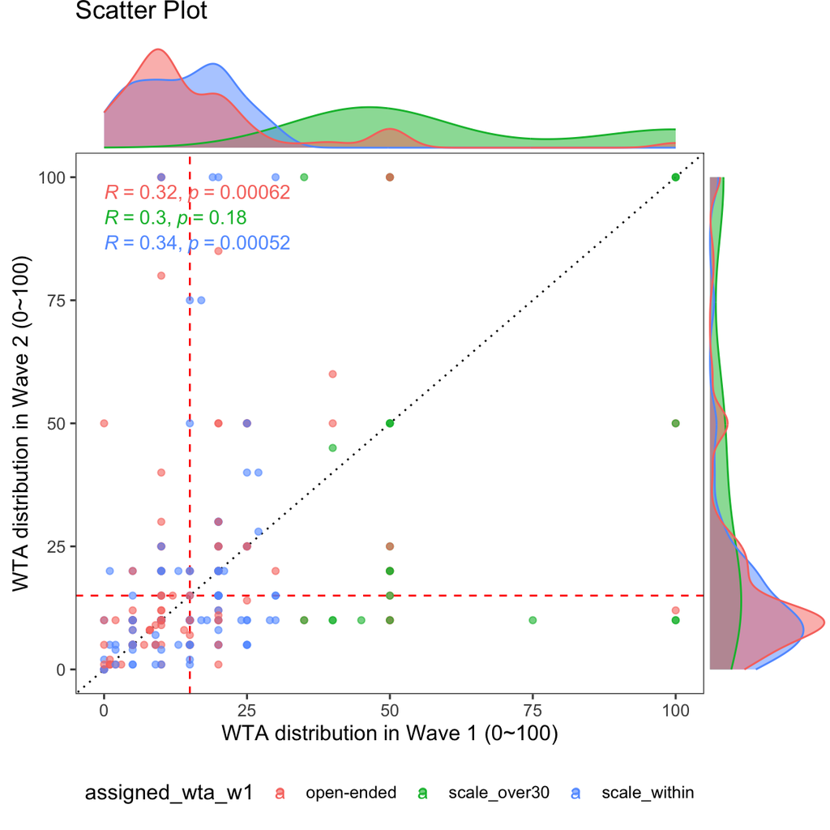

```r
plot1 <- ggplot(wta_df, mapping = aes(wta_w1, wta_w2, col=assigned_wta_w1)) +
  geom_abline(intercept = 0, slope = 1, lty = 3, color = 'black') +
  geom_hline(yintercept = 15, lty = 2, color = 'red') +
  geom_vline(xintercept = 15, lty = 2, color = 'red') +
  geom_point(alpha=0.6) +
  stat_cor(method = 'pearson') +
  xlim(c(0, 100)) +
  ylim(c(0, 100)) +
  theme_few() +
  theme(legend.position = 'bottom') +
  xlab('WTA distribution in Wave 1 (0~100)') +
  ylab('WTA distribution in Wave 2 (0~100)') +
  ggtitle('Scatter Plot')


ggMarginal(plot1, groupColour = TRUE, groupFill = TRUE)
```

## 1.3 Plot 3.

- Group by `category` based on WTA $
  - `always-under15`: user chose below $15 in both waves
  - `always-over15`: user chose $15 or over in both waves
  - `favorable-shift`: user chose $15 or over in wave 1 but shifted below $15 in wave 2
  - `unfavorable-shift`: user chose below $15 in wave 1 but shifted $15 or over in wave 2

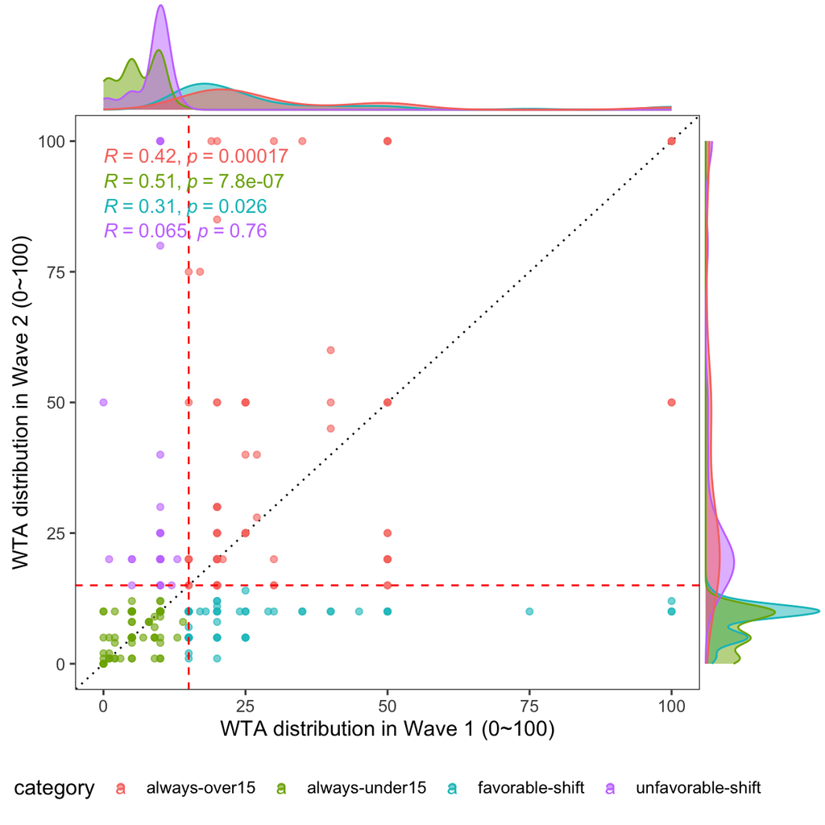

```r
wta_df |>
  mutate(
    category = ifelse(
      wta_w1 < 15 & wta_w2 < 15, "always-under15",
      ifelse(wta_w1 >= 15 & wta_w2 >= 15, "always-over15",
             ifelse(wta_w1 >=15 & wta_w2 < 15, "favorable-shift", "unfavorable-shift")))
    ) |>
    filter(!is.na(wta_w1)) -> wta_df


ggplot(wta_df, mapping = aes(wta_w1, wta_w2, col=category)) +
  geom_abline(intercept = 0, slope = 1, lty = 3, color = 'black') +
  geom_point(alpha=0.6) +
  geom_hline(yintercept = 15, lty = 2, color = 'red') +
  geom_vline(xintercept = 15, lty = 2, color = 'red') +
  theme_few() +
  xlim(c(0, 100)) +
  ylim(c(0, 100)) +
  stat_cor(method = 'pearson') +
  xlab('WTA distribution in Wave 1 (0~100)') +
  ylab('WTA distribution in Wave 2 (0~100)') +
  theme(legend.position='bottom') -> plot2

ggMarginal(plot2, groupColour = TRUE, groupFill = TRUE)
```

## 1.4 Plot 4.

- log10 scales for both x, y axes
- no filtering out those WTA > $100

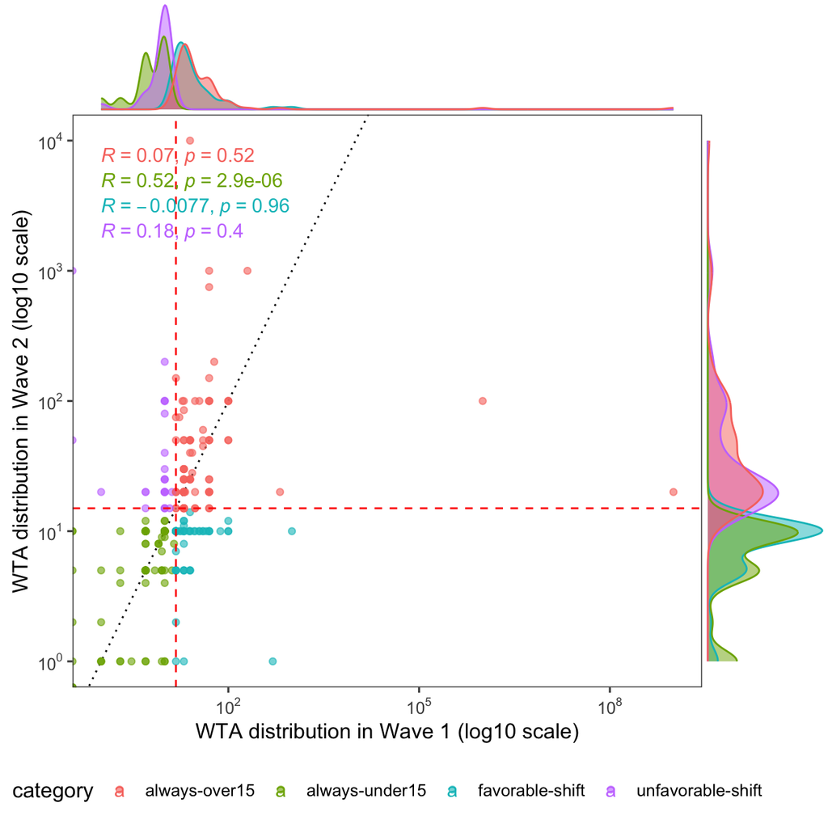

```r
ggplot(wta_df, mapping = aes(wta_w1, wta_w2, col=category)) +
  geom_abline(intercept = 0, slope = 1, lty = 3, color = 'black') +
  geom_point(alpha=0.6) +
  geom_hline(yintercept = 15, lty = 2, color = 'red') +
  geom_vline(xintercept = 15, lty = 2, color = 'red') +
  scale_x_log10(labels = label_log(digits = 2)) +
  scale_y_log10(labels = label_log(digits = 2)) +
  theme_few() +
  stat_cor(method = 'pearson') +
  xlab('WTA distribution in Wave 1 (log10 scale)') +
  ylab('WTA distribution in Wave 2 (log10 scale)') +
  theme(legend.position='bottom') -> plot3

ggMarginal(plot3, groupColour = TRUE, groupFill = TRUE)
```

# 2 Other plots or exploratory analyses based on Wave 1 & 2 responses?

- Any ideas?